# Analysis of the RNA-Seq data by Jang et al.

Simon Anders, March 2017

EMBL Course *Analysis and Integration of Transcriptome and Proteome Data*

# Alternative reading

1. The *DESeq2* package comes with an extensive manual, titled “Differential analysis of count data - the DESeq2 package” (by M. I. Love, S. Anders, W. Huber), available from the R prompt:

```r
library( DESeq2 )
vignette( "DESeq2" )
```

2. The Bioconductor web site offers an intorductory tutorial at http://www.bioconductor.org/help/workflows/rnaseqGene/:

M. I. Love, S. Anders, V. Kim, W. Huber: *RNA-seq workflow: gene-level exploratory analysis and differential expression*

This tutorial has been published a peer-reviewed journal article in F1000 Research 4:1070 (http://doi.org/10.12688/f1000research.7035.2).

# Quick run through

Load package and example “airway” data

```r
library( DESeq2 )
library( airway )
data( airway )
```

The “airway” data set is taken from Himes et al., *RNA-Seq Transcriptome Profiling Identifies CRISPLD2 as a Glucocorticoid Responsive Gene that Modulates Cytokine Function in Airway Smooth Muscle Cells.*, PLoS One, 2014, 13:e99625. Himes et al. used four cell lines derived from airway smooth muscles cells to study transcriptome changes caused by dexamethasone, an immunosuppressive glucocorticoid drug used for bronchospasms (besides other indications).

Look at count table:

```r
head( assay(airway) )
```

```
                SRR1039508 SRR1039509 SRR1039512 SRR1039513 SRR1039516 SRR1039517 SRR1039520
ENSG00000000003        679        448        873        408       1138       1047        770
ENSG00000000005          0          0          0          0          0          0          0
ENSG00000000419        467        515        621        365        587        799        417
ENSG00000000457        260        211        263        164        245        331        233
ENSG00000000460         60         55         40         35         78         63         76
ENSG00000000938          0          0          2          0          1          0          0
                SRR1039521
ENSG00000000003        572
ENSG00000000005          0
ENSG00000000419        508
ENSG00000000457        229
ENSG00000000460         60
ENSG00000000938          0
```

Look at sample table:

```r
colData( airway )
```

```
DataFrame with 8 rows and 9 columns
           SampleName     cell      dex    albut        Run avgLength Experiment    Sample
             <factor> <factor> <factor> <factor>   <factor> <integer>   <factor>  <factor>
SRR1039508 GSM1275862   N61311    untrt    untrt SRR1039508       126  SRX384345 SRS508568
SRR1039509 GSM1275863   N61311      trt    untrt SRR1039509       126  SRX384346 SRS508567
SRR1039512 GSM1275866  N052611    untrt    untrt SRR1039512       126  SRX384349 SRS508571
SRR1039513 GSM1275867  N052611      trt    untrt SRR1039513        87  SRX384350 SRS508572
SRR1039516 GSM1275870  N080611    untrt    untrt SRR1039516       120  SRX384353 SRS508575
SRR1039517 GSM1275871  N080611      trt    untrt SRR1039517       126  SRX384354 SRS508576
SRR1039520 GSM1275874  N061011    untrt    untrt SRR1039520       101  SRX384357 SRS508579
SRR1039521 GSM1275875  N061011      trt    untrt SRR1039521        98  SRX384358 SRS508580
              BioSample
               <factor>
SRR1039508 SAMN02422669
SRR1039509 SAMN02422675
SRR1039512 SAMN02422678
SRR1039513 SAMN02422670
SRR1039516 SAMN02422682
SRR1039517 SAMN02422673
SRR1039520 SAMN02422683
SRR1039521 SAMN02422677
```

(“cell” is the cell line, and “dex” indicated whether the sample was treated with dexamethasone.)

Run DEseq analysis:

```r
dds <- DESeqDataSet( airway, ~ cell + dex )
dds <- DESeq( dds )
res <- results( dds )
```

Show results:

```r
res   # or: View(res)
```

```
log2 fold change (MAP): dex untrt vs trt
Wald test p-value: dex untrt vs trt
DataFrame with 64102 rows and 6 columns
                 baseMean log2FoldChange      lfcSE       stat       pvalue        padj
                <numeric>      <numeric>  <numeric>  <numeric>    <numeric>   <numeric>
ENSG00000000003 708.60217     0.37415246 0.09884435  3.7852692 0.0001535423 0.001289269
ENSG00000000005   0.00000             NA         NA         NA           NA          NA
ENSG00000000419 520.29790    -0.20206175 0.10974241 -1.8412367 0.0655868795 0.197066711
ENSG00000000457 237.16304    -0.03616686 0.13834540 -0.2614244 0.7937652416 0.913856017
ENSG00000000460  57.93263     0.08445399 0.24990709  0.3379415 0.7354072415 0.884141575
...                   ...            ...        ...        ...          ...         ...
LRG_94                  0             NA         NA         NA           NA          NA
LRG_96                  0             NA         NA         NA           NA          NA
LRG_97                  0             NA         NA         NA           NA          NA
LRG_98                  0             NA         NA         NA           NA          NA
LRG_99                  0             NA         NA         NA           NA          NA
```

# Data for this course

As example data, we use the RNA-Seq from the paper *Ribosome profiling reveals an important role for translational control in circadian gene expression* by Jan, Lahens, Hogenesch and Sehgal (Genome Research, 2015, 25:1836).

We first load the full read count table

```r
countsTable <- read.table( "counts.tsv" )
countsTable[ 1:5, 1:5 ]
```

|  | ribo_profile_bmal1_kd_CT00_rep1 | ribo_profile_bmal1_kd_CT02_rep1 | ribo_profile_bmal1_kd_CT04_rep1 | ribo_profile_bmal1_kd_CT06_rep1 | ribo_profile_bmal1_kd_CT08_rep1 |
| --- | --- | --- | --- | --- | --- |
| A1BG | 9 | 16 | 16 | 15 | 25 |
| A1CF | 0 | 2 | 0 | 0 | 0 |
| A2M | 42 | 38 | 36 | 30 | 49 |
| A2ML1 | 1 | 1 | 0 | 2 | 1 |
| A4GALT | 10 | 15 | 8 | 4 | 9 |

Parse column names of count table to make sample table

```r
library( magrittr )
library( tidyverse )
library( stringr )
sampleTable <-
   tibble( colname  = colnames( countsTable ) ) %>%
   mutate( assay = str_extract( colname, "(ribo_profile|totalRNA)" ) ) %>%
   mutate( condition = str_extract( colname, "(bmal1_kd|wt)" ) ) %>%
   mutate( time = str_extract( colname, "CT.." ) ) %>%
   mutate( rep = str_extract( colname, "rep." ) ) %>%
   mutate( sample = str_c( condition, "_", rep ) )
sampleTable
```

| colname | assay | condition | time | rep | sample |
| --- | --- | --- | --- | --- | --- |
| ribo_profile_bmal1_kd_CT00_rep1 | ribo_profile | bmal1_kd | CT00 | rep1 | bmal1_kd_rep1 |
| ribo_profile_bmal1_kd_CT02_rep1 | ribo_profile | bmal1_kd | CT02 | rep1 | bmal1_kd_rep1 |
| ribo_profile_bmal1_kd_CT04_rep1 | ribo_profile | bmal1_kd | CT04 | rep1 | bmal1_kd_rep1 |
| ribo_profile_bmal1_kd_CT06_rep1 | ribo_profile | bmal1_kd | CT06 | rep1 | bmal1_kd_rep1 |
| ribo_profile_bmal1_kd_CT08_rep1 | ribo_profile | bmal1_kd | CT08 | rep1 | bmal1_kd_rep1 |
| ribo_profile_bmal1_kd_CT10_rep1 | ribo_profile | bmal1_kd | CT10 | rep1 | bmal1_kd_rep1 |
| ribo_profile_bmal1_kd_CT12_rep1 | ribo_profile | bmal1_kd | CT12 | rep1 | bmal1_kd_rep1 |
| ribo_profile_bmal1_kd_CT14_rep1 | ribo_profile | bmal1_kd | CT14 | rep1 | bmal1_kd_rep1 |
| ribo_profile_bmal1_kd_CT16_rep1 | ribo_profile | bmal1_kd | CT16 | rep1 | bmal1_kd_rep1 |
| ribo_profile_bmal1_kd_CT18_rep1 | ribo_profile | bmal1_kd | CT18 | rep1 | bmal1_kd_rep1 |

[output cut: 86 more lines]

Make factors and integers

```r
sampleTable$assay %<>% factor %>% relevel( "totalRNA" )
# This is the same as:
#    sampleTable$assay <- relevel( factor( sampleTable$assay ), "totalRNA" )
sampleTable$condition %<>% factor %>% relevel( "wt" )
sampleTable$time %<>% factor
sampleTable$sample %<>% factor
sampleTable$hours <- str_replace( sampleTable$time, "CT", "" ) %>% as.integer
sampleTable
```

| colname | assay | condition | time | rep | sample | hours |
| --- | --- | --- | --- | --- | --- | --- |
| ribo_profile_bmal1_kd_CT00_rep1 | ribo_profile | bmal1_kd | CT00 | rep1 | bmal1_kd_rep1 | 0 |
| ribo_profile_bmal1_kd_CT02_rep1 | ribo_profile | bmal1_kd | CT02 | rep1 | bmal1_kd_rep1 | 2 |
| ribo_profile_bmal1_kd_CT04_rep1 | ribo_profile | bmal1_kd | CT04 | rep1 | bmal1_kd_rep1 | 4 |
| ribo_profile_bmal1_kd_CT06_rep1 | ribo_profile | bmal1_kd | CT06 | rep1 | bmal1_kd_rep1 | 6 |
| ribo_profile_bmal1_kd_CT08_rep1 | ribo_profile | bmal1_kd | CT08 | rep1 | bmal1_kd_rep1 | 8 |
| ribo_profile_bmal1_kd_CT10_rep1 | ribo_profile | bmal1_kd | CT10 | rep1 | bmal1_kd_rep1 | 10 |
| ribo_profile_bmal1_kd_CT12_rep1 | ribo_profile | bmal1_kd | CT12 | rep1 | bmal1_kd_rep1 | 12 |
| ribo_profile_bmal1_kd_CT14_rep1 | ribo_profile | bmal1_kd | CT14 | rep1 | bmal1_kd_rep1 | 14 |
| ribo_profile_bmal1_kd_CT16_rep1 | ribo_profile | bmal1_kd | CT16 | rep1 | bmal1_kd_rep1 | 16 |
| ribo_profile_bmal1_kd_CT18_rep1 | ribo_profile | bmal1_kd | CT18 | rep1 | bmal1_kd_rep1 | 18 |

[output cut: 86 more lines]

We put this together into a DESeq data object

```r
library( DESeq2 )
dds <- DESeqDataSetFromMatrix( countsTable, sampleTable, ~1 )
# ( "~1" is just a place holder for the design formula which we will add later)
dds
```

```
class: DESeqDataSet
dim: 19438 96
metadata(1): version
assays(1): counts
rownames(19438): A1BG A1CF ... ZZEF1 ZZZ3
rowData names(0):
colnames(96): ribo_profile_bmal1_kd_CT00_rep1 ribo_profile_bmal1_kd_CT02_rep1 ...
  totalRNA_wt_CT20_rep2 totalRNA_wt_CT22_rep2
colData names(7): colname assay ... sample hours
```

# Normalization

Pick two arbitrary libraries, plot them against each other

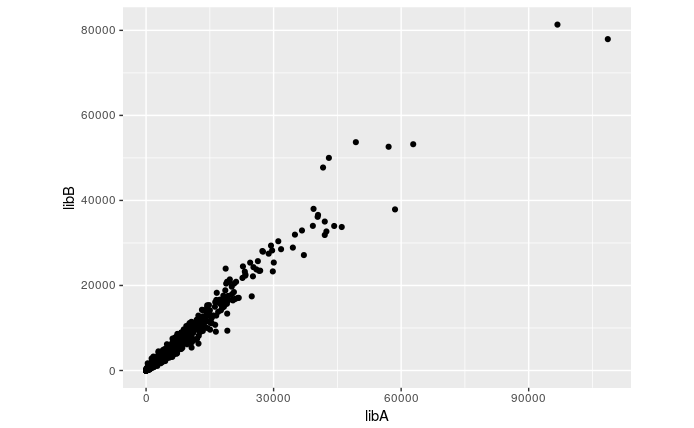

```r
library( ggplot2 )
df <- data.frame(
   libA = counts(dds)[,"totalRNA_wt_CT06_rep2"],
   libB = counts(dds)[,"totalRNA_wt_CT12_rep1"] )

ggplot( df ) +
   geom_point(aes(
      x = libA,
      y = libB )) +
   coord_fixed()
```

HOw does this look with logarithmic axes?

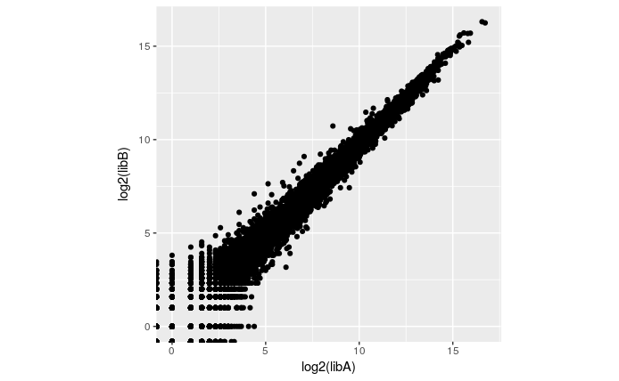

```r
ggplot( df ) +
   geom_point(aes(
      x = log2( libA ),
      y = log2( libB ) )) +
   coord_fixed()
```

Turn by 45 degrees (“MA plot”)

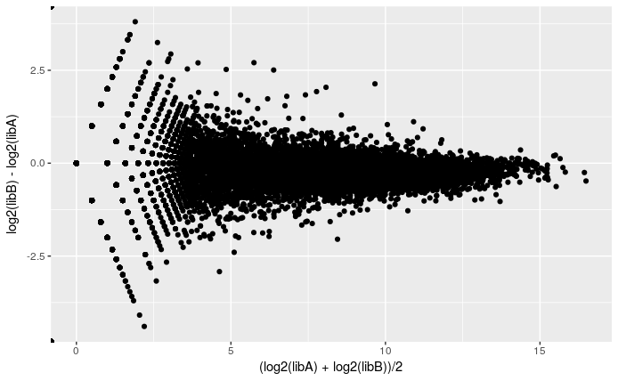

```r
ggplot( df ) +
   geom_point(aes(
      x = ( log2(libA) + log2(libB) )/2,
      y = log2(libB) - log2(libA) ) )
```

Make points semi-transparent, add horizaontal line at 0

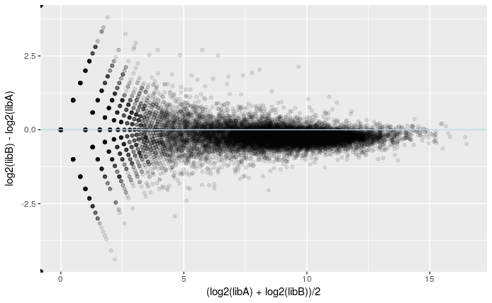

```r
ggplot( df ) +
   geom_point(
      aes(
         x = ( log2(libA) + log2(libB) )/2,
         y = log2(libB) - log2(libA) ),
      alpha = .1 ) +
   geom_hline( yintercept = 0, col="lightblue" )
```

Show histogram of log ratioos (“log fold changes”):

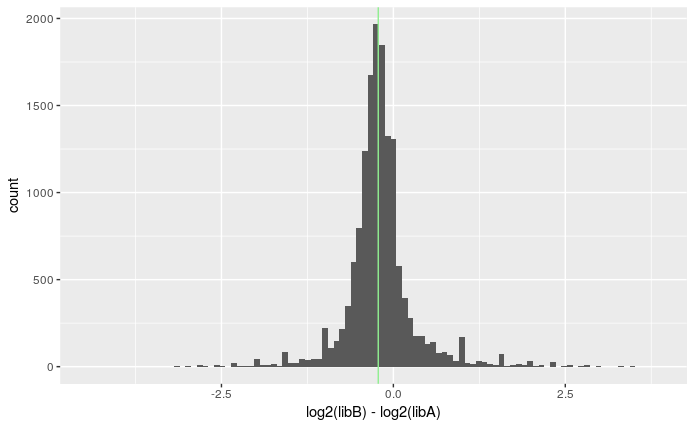

```r
ggplot( df ) +
   geom_histogram(
      aes( x = log2(libB) - log2(libA) ),
      bins=100) +
   geom_vline(
      xintercept = median( log2(df$libB) - log2(df$libA), na.rm=TRUE ),
      col="lightgreen" )
```

Back to DESeq2: Calculate size factors to normalize the counts

```r
dds <- estimateSizeFactors( dds )
sizeFactors(dds)
```

```
ribo_profile_bmal1_kd_CT00_rep1 ribo_profile_bmal1_kd_CT02_rep1 ribo_profile_bmal1_kd_CT04_rep1
                      0.3465557                       0.4624126                       0.4014767
ribo_profile_bmal1_kd_CT06_rep1 ribo_profile_bmal1_kd_CT08_rep1 ribo_profile_bmal1_kd_CT10_rep1
                      0.4515944                       0.3965577                       0.4726393
ribo_profile_bmal1_kd_CT12_rep1 ribo_profile_bmal1_kd_CT14_rep1 ribo_profile_bmal1_kd_CT16_rep1
                      0.3987989                       0.4680781                       0.4614400
ribo_profile_bmal1_kd_CT18_rep1 ribo_profile_bmal1_kd_CT20_rep1 ribo_profile_bmal1_kd_CT22_rep1
                      0.4459409                       0.4789512                       0.4001094
ribo_profile_bmal1_kd_CT00_rep2 ribo_profile_bmal1_kd_CT02_rep2 ribo_profile_bmal1_kd_CT04_rep2
                      0.4010039                       0.4973839                       0.3434802
ribo_profile_bmal1_kd_CT06_rep2 ribo_profile_bmal1_kd_CT08_rep2 ribo_profile_bmal1_kd_CT10_rep2
                      0.3992826                       0.4908933                       0.4891284
ribo_profile_bmal1_kd_CT12_rep2 ribo_profile_bmal1_kd_CT14_rep2 ribo_profile_bmal1_kd_CT16_rep2
                      0.4784430                       0.5358208                       0.5665040
ribo_profile_bmal1_kd_CT18_rep2 ribo_profile_bmal1_kd_CT20_rep2 ribo_profile_bmal1_kd_CT22_rep2
                      0.4885102                       0.3322595                       0.5257573
    totalRNA_bmal1_kd_CT00_rep1     totalRNA_bmal1_kd_CT02_rep1     totalRNA_bmal1_kd_CT04_rep1
                      1.8979314                       2.3376702                       2.3782999
    totalRNA_bmal1_kd_CT06_rep1     totalRNA_bmal1_kd_CT08_rep1     totalRNA_bmal1_kd_CT10_rep1
                      2.8161530                       1.9362964                       2.3222649
    totalRNA_bmal1_kd_CT12_rep1     totalRNA_bmal1_kd_CT14_rep1     totalRNA_bmal1_kd_CT16_rep1
                      2.5448070                       2.5115161                       2.5267406
    totalRNA_bmal1_kd_CT18_rep1     totalRNA_bmal1_kd_CT20_rep1     totalRNA_bmal1_kd_CT22_rep1
                      2.1417280                       2.0371742                       2.0866561
    totalRNA_bmal1_kd_CT00_rep2     totalRNA_bmal1_kd_CT02_rep2     totalRNA_bmal1_kd_CT04_rep2
                      2.2571513                       2.1699367                       2.2574954
    totalRNA_bmal1_kd_CT06_rep2     totalRNA_bmal1_kd_CT08_rep2     totalRNA_bmal1_kd_CT10_rep2
                      2.1660943                       2.2806706                       2.0313576
    totalRNA_bmal1_kd_CT12_rep2     totalRNA_bmal1_kd_CT14_rep2     totalRNA_bmal1_kd_CT16_rep2
                      2.3152504                       0.3710183                       2.4722300
    totalRNA_bmal1_kd_CT18_rep2     totalRNA_bmal1_kd_CT20_rep2     totalRNA_bmal1_kd_CT22_rep2
                      0.3683576                       2.4594355                       2.6747912
      ribo_profile_wt_CT00_rep1       ribo_profile_wt_CT02_rep1       ribo_profile_wt_CT04_rep1
                      0.6425957                       0.4456603                       0.5124545
      ribo_profile_wt_CT06_rep1       ribo_profile_wt_CT08_rep1       ribo_profile_wt_CT10_rep1
                      0.6049381                       0.6466289                       0.5167099
      ribo_profile_wt_CT12_rep1       ribo_profile_wt_CT14_rep1       ribo_profile_wt_CT16_rep1
                      0.6404631                       0.5119659                       0.3282624
      ribo_profile_wt_CT18_rep1       ribo_profile_wt_CT20_rep1       ribo_profile_wt_CT22_rep1
                      0.3658795                       0.5195883                       0.7655149
```

[output cut: 9 more lines]

```
                      2.4126623                       2.4165442                       2.2298261
          totalRNA_wt_CT06_rep1           totalRNA_wt_CT08_rep1           totalRNA_wt_CT10_rep1
                      2.4221050                       2.2932855                       2.2484549
          totalRNA_wt_CT12_rep1           totalRNA_wt_CT14_rep1           totalRNA_wt_CT16_rep1
                      2.0967116                       2.4385405                       2.0906914
          totalRNA_wt_CT18_rep1           totalRNA_wt_CT20_rep1           totalRNA_wt_CT22_rep1
                      2.0331589                       2.3605240                       2.3736674
          totalRNA_wt_CT00_rep2           totalRNA_wt_CT02_rep2           totalRNA_wt_CT04_rep2
                      2.0791957                       2.1887560                       2.1853808
          totalRNA_wt_CT06_rep2           totalRNA_wt_CT08_rep2           totalRNA_wt_CT10_rep2
                      2.4611388                       2.2170260                       2.4277992
          totalRNA_wt_CT12_rep2           totalRNA_wt_CT14_rep2           totalRNA_wt_CT16_rep2
                      2.2162822                       2.4332707                       2.3606104
          totalRNA_wt_CT18_rep2           totalRNA_wt_CT20_rep2           totalRNA_wt_CT22_rep2
                      2.4592866                       2.2159423                       2.1112988
```

Plot them

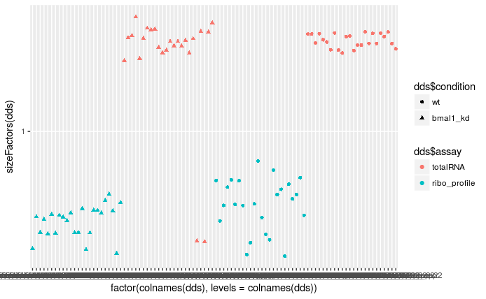

Identify the two outliers

```r
which( sizeFactors(dds) < 1 & dds$assay == "totalRNA" )
```

```
totalRNA_bmal1_kd_CT14_rep2 totalRNA_bmal1_kd_CT18_rep2
                         44                          46
```

MA plot of the normalized counts

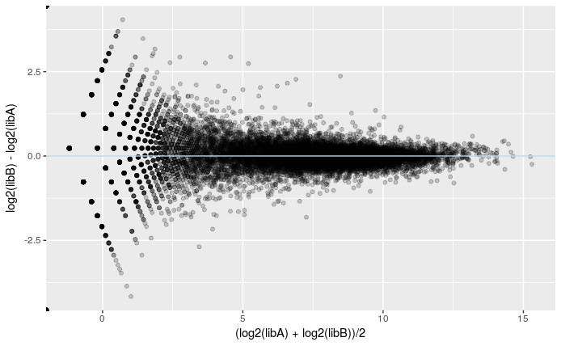

```r
dfn <- data.frame(
   libA = counts( dds, normalized=TRUE )[,"totalRNA_wt_CT06_rep2"],
   libB = counts( dds, normalized=TRUE )[,"totalRNA_wt_CT12_rep1"] )
ggplot( dfn ) +
   geom_point(
      aes(
         x = ( log2(libA) + log2(libB) )/2,
         y = log2(libB) - log2(libA) ),
      alpha = .2 ) +
   geom_hline( yintercept = 0, col="lightblue" )
```

# Sample distances

Calculate a *distance matrix*, quantifying dissimilarity of the samples

```r
distmat <- as.matrix(dist(t( log2( 10 + counts(dds) ) )))
View( distmat )
```

Visualize the distance matrix as heatmap

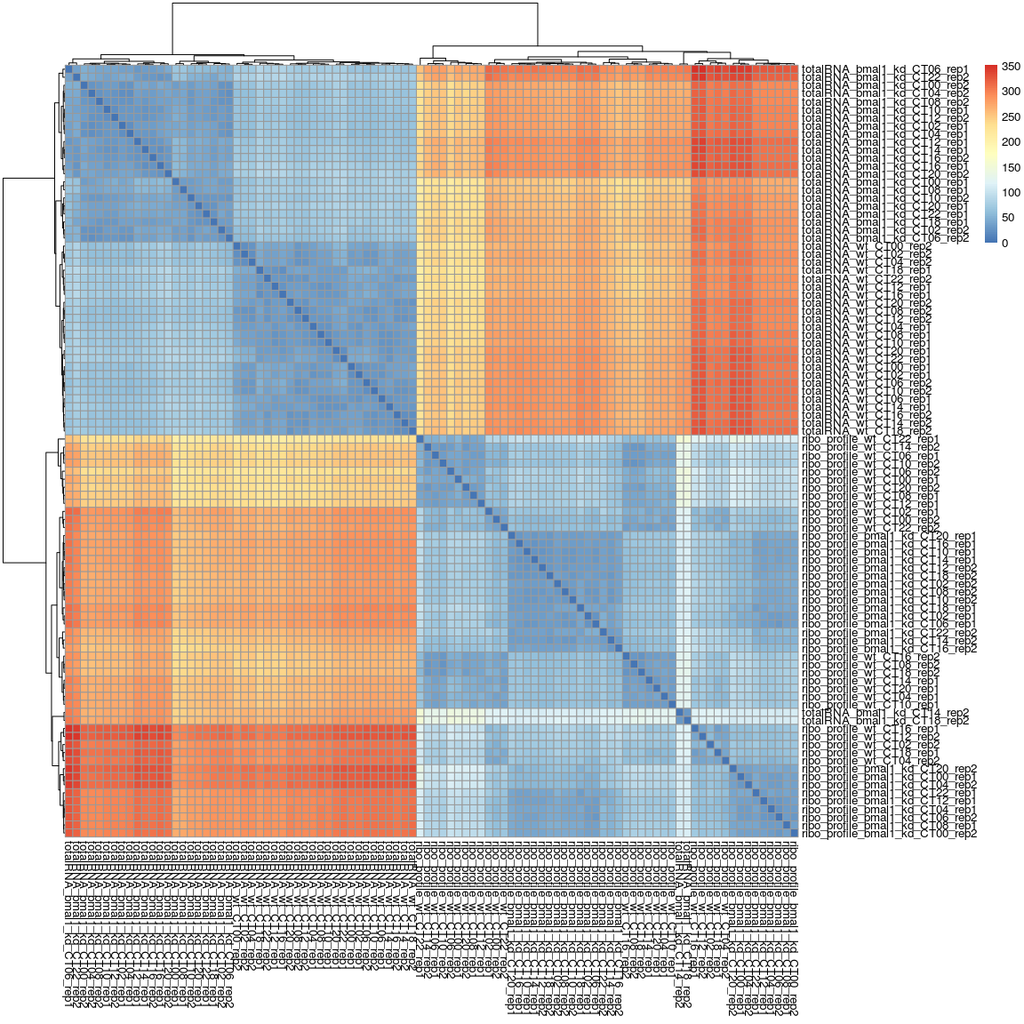

```r
library( pheatmap )
pheatmap( distmat )
```

Switch off clustering

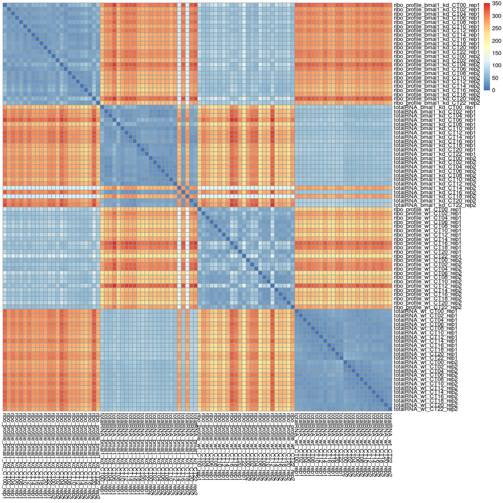

Heatmap only for the totalRNA samples

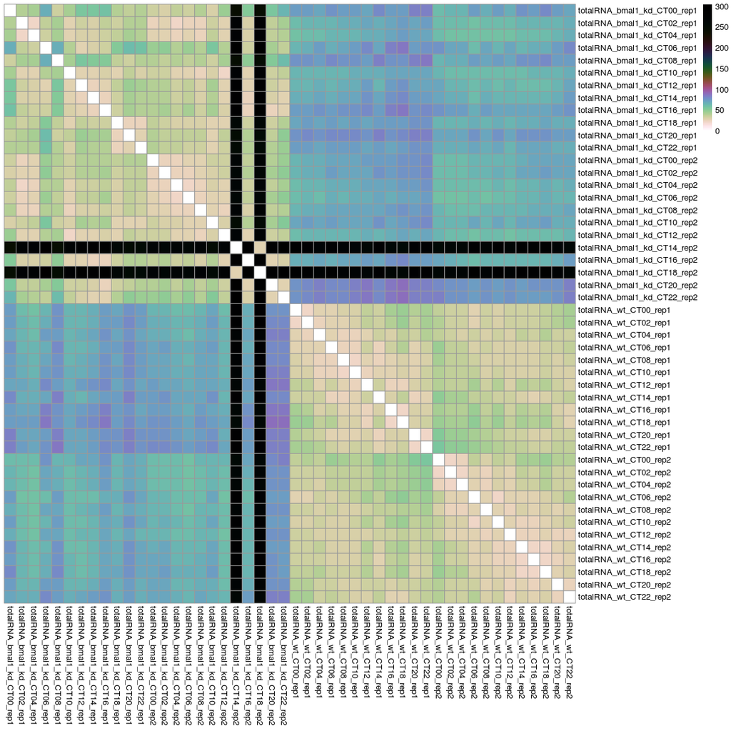

```r
ddsRNA <- dds[ , dds$assay == "totalRNA" ]
distmatRNA <- as.matrix(dist(t( log2( 10 + counts(ddsRNA) ) )))
pheatmap( distmatRNA, cluster_rows=FALSE, cluster_cols=FALSE,
   col = rev(rje::cubeHelix( 100, r=-3, gamma=2 )) )
```

ow only the wild-type totalRNA samples. ALso use a nicer color scale

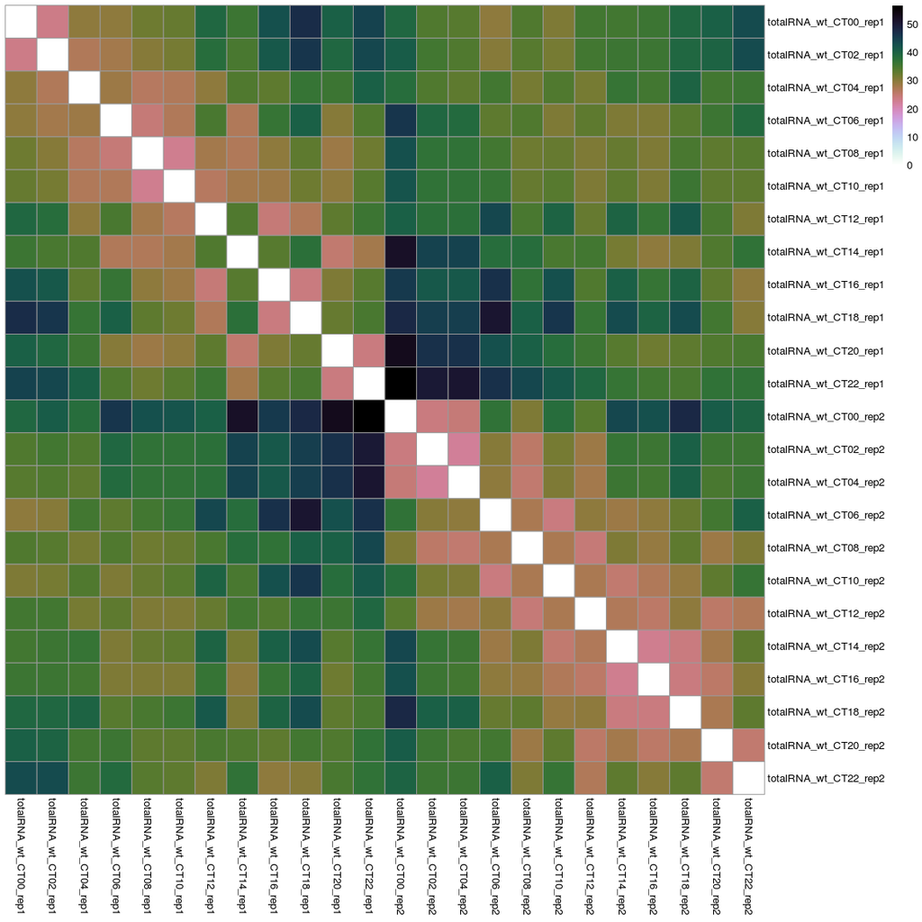

```r
ddsRNAwt <- dds[ , dds$assay == "totalRNA" & dds$condition == "wt" ]
distmatRNAwt <- as.matrix(dist(t( log2( 10 + counts(ddsRNAwt) ) )))
pheatmap( distmatRNAwt, cluster_rows=FALSE, cluster_cols=FALSE,
   col = rev(rje::cubeHelix( 100 )) )
```

# Simple two-group comparison

To first demonstrate the simplest possible analysis, let’s pretend we have only two types of samples: total RNA from samples treated with siRNA and untreated controls, both incubated 10 hours.

Subset the full data to these samples

```r
dds10 <- dds[ , dds$time == "CT10" & dds$assay == "totalRNA" ]
colData( dds10 )
```

```
DataFrame with 4 rows and 8 columns
                                                colname    assay condition     time         rep
                                            <character> <factor>  <factor> <factor> <character>
totalRNA_bmal1_kd_CT10_rep1 totalRNA_bmal1_kd_CT10_rep1 totalRNA  bmal1_kd     CT10        rep1
totalRNA_bmal1_kd_CT10_rep2 totalRNA_bmal1_kd_CT10_rep2 totalRNA  bmal1_kd     CT10        rep2
totalRNA_wt_CT10_rep1             totalRNA_wt_CT10_rep1 totalRNA        wt     CT10        rep1
totalRNA_wt_CT10_rep2             totalRNA_wt_CT10_rep2 totalRNA        wt     CT10        rep2
                                   sample     hours sizeFactor
                                 <factor> <integer>  <numeric>
totalRNA_bmal1_kd_CT10_rep1 bmal1_kd_rep1        10   2.322265
totalRNA_bmal1_kd_CT10_rep2 bmal1_kd_rep2        10   2.031358
totalRNA_wt_CT10_rep1             wt_rep1        10   2.248455
totalRNA_wt_CT10_rep2             wt_rep2        10   2.427799
```

Comparing two types of samples, wich differ by a single covariate (here: `condition`), (“a two-group comparison”) is straight-forward.

Set the comparison type, i.e. indicate which column in the colData table contains the group information

```r
design(dds10) <- ~ condition
```

Run the analysis

```r
dds10 <- DESeq( dds10 )
```

Get the results

```r
res10 <- results( dds10 )
res10  # or: View( res10 )
```

```
log2 fold change (MAP): condition bmal1_kd vs wt
Wald test p-value: condition bmal1_kd vs wt
DataFrame with 19438 rows and 6 columns
           baseMean log2FoldChange     lfcSE       stat       pvalue         padj
          <numeric>      <numeric> <numeric>  <numeric>    <numeric>    <numeric>
A1BG    107.6914498     0.58857829 0.2374320  2.4789339   0.01317757   0.05109543
A1CF      0.2059478    -0.05368265 0.1002924 -0.5352616   0.59246898           NA
A2M      68.4520946    -0.61008532 0.3566374 -1.7106601   0.08714389   0.22189783
A2ML1     0.0000000             NA        NA         NA           NA           NA
A4GALT   28.9242515     0.14860576 0.3310453  0.4488985   0.65350487   0.82022362
...             ...            ...       ...        ...          ...          ...
ZYG11A    0.1111875    -0.02680823 0.1001785 -0.2676046 7.890037e-01           NA
ZYG11B  779.3420561    -0.48451153 0.1151802 -4.2065535 2.592947e-05 0.0002363819
ZYX     339.4781009     0.41330645 0.1588635  2.6016451 9.277780e-03 0.0383582606
ZZEF1   342.5472004    -0.02377247 0.1522773 -0.1561130 8.759439e-01 0.9425311481
ZZZ3   1078.7399661    -0.30000414 0.1098110 -2.7320036 6.295045e-03 0.0279393031
```

MA plot

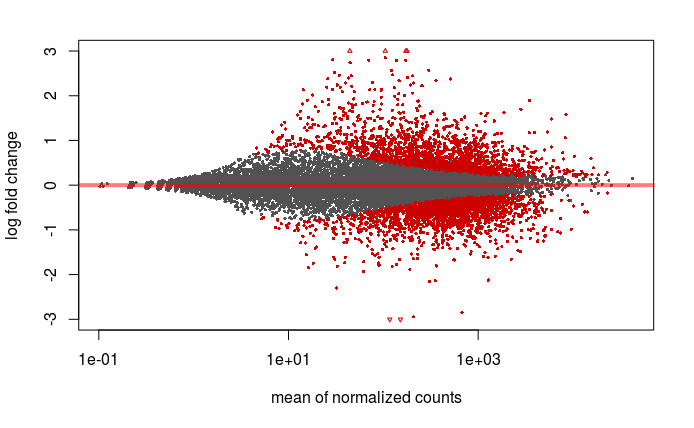

```r
plotMA( res10, ylim=c( -3, 3 ) )
```

Visualize a given gene

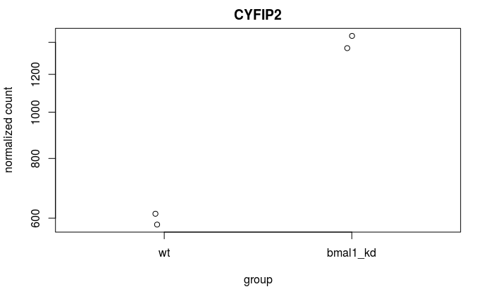

Alternatively, with ggplot2:

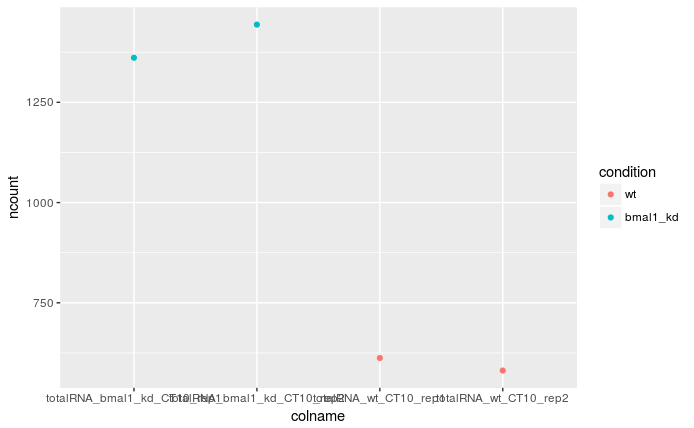

```r
data.frame(
   colData(dds10),
   ncount = counts( dds10, normalized=TRUE )["CYFIP2",] ) %>%
ggplot +
   geom_point(aes(
      x = colname,
      y = ncount,
      col = condition ) )
```

Dispersion plot

```r
plotDispEsts( dds10 )
```

[output not shown]

# Paired comparison

Often, samples are paired. To have example of such a case, let’s consider this subset of our data, comtaining two sample pairs:

```r
ddsP <- dds[ , dds$assay == "totalRNA" & dds$condition == "wt" & dds$time %in% c( "CT00", "CT10" ) ]

ddsP$sample <- factor( paste( ddsP$condition, ddsP$rep, sep="_" ) )
ddsP$time <- droplevels( ddsP$time )

colData(ddsP)
```

Each pair is one sample, with one aliquot taken at 0 h and another at 10 h incubation. We want to see which genes change during the incubation.

A simple approach is this:

```r
design( ddsP ) <- ~ time

ddsP <- DESeq( ddsP )

summary( results( ddsP ) )
```

We gain power by exploiting that the samples are *paired*:

```r
design( ddsP ) <- ~ sample + time

ddsP <- DESeq( ddsP )

summary( results( ddsP ) )
```

Note: This is a bad example: We have subset to a mere two samples, and this is too few! The airway example used at the beginning has four library pairs, is a better example of good practice.

To understand how to deal with more complex designs, it is helpful to understand the *model matrix* (a.k.a. *design matrix) arising from the formula above

```r
model.matrix( ~ sample + time, colData(ddsP) )
```

**Side note:** To allow for DEseq2’s effect-size shrinkage, the design matrix actually used looks somewhat different:

```r
attr( ddsP, "modelMatrix" )
```

Switching off effect-size shrinkage recovers the standard matrix

```r
ddsP <- DESeq( ddsP, betaPrior=FALSE )
attr( ddsP, "modelMatrix" )
```

# Ribosomal profiling

This time, we take this subset:

```r
ddsR <- dds[ , dds$time == "CT10" ]
colData(ddsR)
```

```
DataFrame with 8 rows and 8 columns
                                                        colname        assay condition     time
                                                    <character>     <factor>  <factor> <factor>
ribo_profile_bmal1_kd_CT10_rep1 ribo_profile_bmal1_kd_CT10_rep1 ribo_profile  bmal1_kd     CT10
ribo_profile_bmal1_kd_CT10_rep2 ribo_profile_bmal1_kd_CT10_rep2 ribo_profile  bmal1_kd     CT10
totalRNA_bmal1_kd_CT10_rep1         totalRNA_bmal1_kd_CT10_rep1     totalRNA  bmal1_kd     CT10
totalRNA_bmal1_kd_CT10_rep2         totalRNA_bmal1_kd_CT10_rep2     totalRNA  bmal1_kd     CT10
ribo_profile_wt_CT10_rep1             ribo_profile_wt_CT10_rep1 ribo_profile        wt     CT10
ribo_profile_wt_CT10_rep2             ribo_profile_wt_CT10_rep2 ribo_profile        wt     CT10
totalRNA_wt_CT10_rep1                     totalRNA_wt_CT10_rep1     totalRNA        wt     CT10
totalRNA_wt_CT10_rep2                     totalRNA_wt_CT10_rep2     totalRNA        wt     CT10
                                        rep        sample     hours sizeFactor
                                <character>      <factor> <integer>  <numeric>
ribo_profile_bmal1_kd_CT10_rep1        rep1 bmal1_kd_rep1        10  0.4726393
ribo_profile_bmal1_kd_CT10_rep2        rep2 bmal1_kd_rep2        10  0.4891284
totalRNA_bmal1_kd_CT10_rep1            rep1 bmal1_kd_rep1        10  2.3222649
totalRNA_bmal1_kd_CT10_rep2            rep2 bmal1_kd_rep2        10  2.0313576
ribo_profile_wt_CT10_rep1              rep1       wt_rep1        10  0.5167099
ribo_profile_wt_CT10_rep2              rep2       wt_rep2        10  0.5925682
totalRNA_wt_CT10_rep1                  rep1       wt_rep1        10  2.2484549
totalRNA_wt_CT10_rep2                  rep2       wt_rep2        10  2.4277992
```

This time, we construct the model matrix by hand

```r
mm <- model.matrix( ~ 0 + sample + assay + assay:condition, colData(ddsR) )
mm <- mm[ , -6 ]
mm
```

```
                                samplebmal1_kd_rep1 samplebmal1_kd_rep2 samplewt_rep1
ribo_profile_bmal1_kd_CT10_rep1                   1                   0             0
ribo_profile_bmal1_kd_CT10_rep2                   0                   1             0
totalRNA_bmal1_kd_CT10_rep1                       1                   0             0
totalRNA_bmal1_kd_CT10_rep2                       0                   1             0
ribo_profile_wt_CT10_rep1                         0                   0             1
ribo_profile_wt_CT10_rep2                         0                   0             0
totalRNA_wt_CT10_rep1                             0                   0             1
totalRNA_wt_CT10_rep2                             0                   0             0
                                samplewt_rep2 assayribo_profile
ribo_profile_bmal1_kd_CT10_rep1             0                 1
ribo_profile_bmal1_kd_CT10_rep2             0                 1
totalRNA_bmal1_kd_CT10_rep1                 0                 0
totalRNA_bmal1_kd_CT10_rep2                 0                 0
ribo_profile_wt_CT10_rep1                   0                 1
ribo_profile_wt_CT10_rep2                   1                 1
totalRNA_wt_CT10_rep1                       0                 0
totalRNA_wt_CT10_rep2                       1                 0
                                assayribo_profile:conditionbmal1_kd
ribo_profile_bmal1_kd_CT10_rep1                                   1
ribo_profile_bmal1_kd_CT10_rep2                                   1
totalRNA_bmal1_kd_CT10_rep1                                       0
totalRNA_bmal1_kd_CT10_rep2                                       0
ribo_profile_wt_CT10_rep1                                         0
ribo_profile_wt_CT10_rep2                                         0
totalRNA_wt_CT10_rep1                                             0
totalRNA_wt_CT10_rep2                                             0
```

Run DESeq and get results (by default, with respect to the last column of the model matrix)

```r
summary( resR )
```

```
out of 17083 with nonzero total read count
adjusted p-value < 0.1
LFC > 0 (up)     : 12, 0.07%
LFC < 0 (down)   : 49, 0.29%
outliers [1]     : 0, 0%
low counts [2]   : 16111, 94%
(mean count < 1563)
[1] see 'cooksCutoff' argument of ?results
[2] see 'independentFiltering' argument of ?results
```

Show genes with significant increase in translational efficiency:

```r
resR[ which( resR$log2FoldChange > 0 & resR$padj < .1 ), ]
```

```
log2 fold change (MLE): assayribo profile.conditionbmal1 kd
Wald test p-value: assayribo profile.conditionbmal1 kd
DataFrame with 12 rows and 6 columns
        baseMean log2FoldChange     lfcSE      stat       pvalue         padj
       <numeric>      <numeric> <numeric> <numeric>    <numeric>    <numeric>
CENPF   3654.739      0.3950017 0.1353511  2.918348 3.518910e-03  0.077797558
DST     1889.293      0.4902468 0.1602844  3.058605 2.223698e-03  0.056879852
EIF5B   1829.506      0.7447175 0.1837738  4.052360 5.070361e-05  0.002142779
FLNB    2325.422      0.4504621 0.1456637  3.092479 1.984922e-03  0.053592905
HNRNPM  3835.856      0.4106082 0.1435895  2.859597 4.241800e-03  0.080843727
...          ...            ...       ...       ...          ...          ...
NOP56   2238.840      0.4139016 0.1485441  2.786389 5.329888e-03 9.088862e-02
PLEC    7541.874      0.7087886 0.1188853  5.961954 2.492389e-09 8.075341e-07
PRKDC   6960.168      0.3538811 0.1208085  2.929273 3.397560e-03 7.779756e-02
RANBP2  1773.217      0.4708413 0.1603767  2.935846 3.326396e-03 7.779756e-02
TPR     2201.860      0.4108364 0.1450938  2.831523 4.632685e-03 8.422273e-02
```

Show genes with significant decrease in translational efficiency:

```r
as.data.frame( resR[ which( resR$log2FoldChange < 0 & resR$padj < .1 ), ] )
```

|  | baseMean | log2FoldChange | lfcSE | stat | pvalue | padj |
| --- | --- | --- | --- | --- | --- | --- |
| ARPC1B | 1893.575 | -0.5290451 | 0.1534629 | -3.447382 | 5.660485e-04 | 1.833997e-02 |
| C17orf76-AS1 | 1799.589 | -0.5826254 | 0.2011278 | -2.896792 | 3.769996e-03 | 7.779756e-02 |
| CAV1 | 3635.471 | -0.3562589 | 0.1292928 | -2.755444 | 5.861261e-03 | 9.495243e-02 |
| CHCHD2 | 2742.128 | -0.4605178 | 0.1477043 | -3.117837 | 1.821837e-03 | 5.059503e-02 |
| COX6B1 | 1674.947 | -0.4164627 | 0.1522652 | -2.735115 | 6.235854e-03 | 9.936476e-02 |
| EEF1G | 5439.024 | -0.4069140 | 0.1329217 | -3.061306 | 2.203735e-03 | 5.687985e-02 |
| ERH | 2508.592 | -0.4062874 | 0.1451393 | -2.799294 | 5.121456e-03 | 9.042824e-02 |
| H1FX | 2332.205 | -0.5519755 | 0.1697830 | -3.251065 | 1.149737e-03 | 3.386499e-02 |
| H3F3B | 4159.617 | -0.3754594 | 0.1356571 | -2.767709 | 5.645182e-03 | 9.300198e-02 |
| HIST1H2BD | 3502.187 | -0.4491728 | 0.1565569 | -2.869071 | 4.116797e-03 | 8.003053e-02 |

[output cut: 39 more lines]

Plot an example

```
Arguments in '...' ignored
```

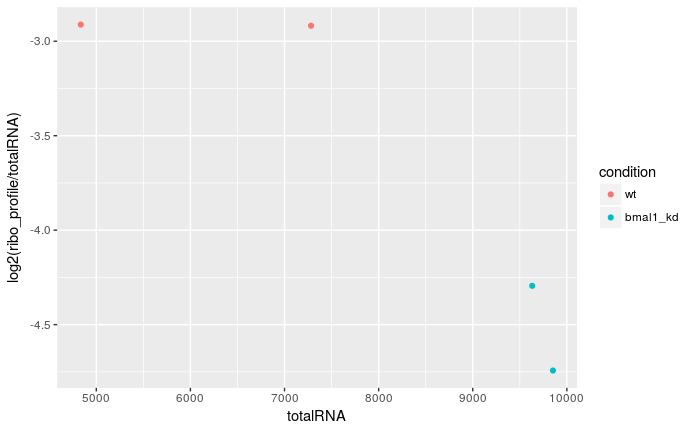

```r
as_tibble( colData(ddsR) ) %>%
   mutate( ncount = counts( ddsR, normalized=TRUE )[ "MT1E", ] ) %>%
   select( condition, sample, assay, ncount ) %>%
   spread( assay, ncount ) %>%
ggplot +
   geom_point(aes(
      x = totalRNA,
      y = log2( ribo_profile / totalRNA ),
      col=condition ) )
```

# Limma/Voom

Two other popular tools for differential expression analysis of RNA-Seq data are *edgeR* (McCarthy et al., 2012, Nucl Acid Res 40:4288) and *Voom* (Law et al, 2014, Genome Res 15:R29), both from G. Smyth’s group in Melbourne. Here, I repeat the previous analysis with voom:

|  | logFC | AveExpr | t | P.Value | adj.P.Val | B |
| --- | --- | --- | --- | --- | --- | --- |
| PABPC4 | -0.8005162 | 7.620925 | -13.06968 | 0.0001382549 | 0.4837495 | 2.018113 |
| RPS24 | -0.7525207 | 9.669588 | -12.88305 | 0.0001467645 | 0.4837495 | 1.957766 |
| SPTAN1 | 1.6770370 | 6.545503 | 13.03427 | 0.0001398220 | 0.4837495 | 1.935581 |
| GNG5 | -1.0149869 | 5.937157 | -13.19437 | 0.0001329067 | 0.4837495 | 1.932306 |
| RPL38 | -0.8686738 | 7.555819 | -12.27458 | 0.0001793759 | 0.4837495 | 1.760994 |
| RPLP0 | -0.7538351 | 9.214520 | -11.92666 | 0.0002020528 | 0.4837495 | 1.651504 |
| PLEC | 0.7254705 | 9.928484 | 11.95217 | 0.0002002742 | 0.4837495 | 1.613567 |
| RPL29 | -0.7953199 | 7.974510 | -10.55150 | 0.0003348715 | 0.4837495 | 1.143789 |
| MT1E | -1.5753896 | 8.146904 | -10.30536 | 0.0003689560 | 0.4837495 | 1.058831 |
| TIMM8B | -0.7225059 | 6.683722 | -10.21754 | 0.0003821391 | 0.4837495 | 1.024204 |

Limma has not deemed anything significant. Note, however, that this is a not a good example due to the small sample number.

# Repeated measures

There are two kinds of time series: (a) A number of independent samples are incubated for different times, and (b) one sample is incubated for the full time, and libraries are prepared from aliquots taken at each time step. In the latter case, these libraries will be correlated simply due to stemming from the same sample. Standard GLMs (as performed by DESeq and edgeR) fail to account for this, and may produce very over-optimistic p values. Limma offers a function, “duplicateCorrelation”, to estimate the strength for this correlation and then account for it.

For a full analysis of the data, we should hence use limma/voom. For independent-samples time series, DESeq ca ne used, and the user manual contains a chapter on this topic.

# Time-series analysis, RNA only

This section merely runs quickly through a limma/voom analysis of the full set of totalRNA samples, to find cycling genes, i.e., genes whose expression follows the circadian rhythm.

First, only the wildtype samples.

```r
head( mmRw )
```

```
                      (Intercept) hours cos(hours/24 * 2 * pi) sin(hours/24 * 2 * pi)
totalRNA_wt_CT00_rep1           1     0           1.000000e+00              0.0000000
totalRNA_wt_CT02_rep1           1     2           8.660254e-01              0.5000000
totalRNA_wt_CT04_rep1           1     4           5.000000e-01              0.8660254
totalRNA_wt_CT06_rep1           1     6           6.123234e-17              1.0000000
totalRNA_wt_CT08_rep1           1     8          -5.000000e-01              0.8660254
totalRNA_wt_CT10_rep1           1    10          -8.660254e-01              0.5000000
```

This model matrix is designed to catch oscillation with a 24 h period, in the manner of a Forier analysis. Genes that merely drift with time will be fitted well with only the first two columns. An F test for significance of columns 3:4 will test for oscillation.

|  | cos.hours.24...2...pi. | sin.hours.24...2...pi. | AveExpr | F | P.Value | adj.P.Val |
| --- | --- | --- | --- | --- | --- | --- |
| ARNTL | 0.3484624 | -0.7991740 | 3.7408197 | 131.15670 | 2.339138e-13 | 4.546817e-09 |
| PER2 | -0.4613637 | 0.8856513 | 2.6027080 | 104.22740 | 2.632767e-12 | 2.558787e-08 |
| NR1D2 | 0.2655941 | 0.5918646 | 6.1213698 | 81.36948 | 3.357972e-11 | 2.175742e-07 |
| PER3 | -0.4289541 | 0.5391118 | 4.4539053 | 65.39527 | 2.980880e-10 | 1.448559e-06 |
| TEF | -0.1049680 | 0.9748184 | 4.1833566 | 61.60670 | 5.347426e-10 | 2.078865e-06 |
| CRY2 | -0.2324442 | 0.4732758 | 3.4268855 | 41.53705 | 2.187380e-08 | 7.086381e-05 |
| AL157440 | -0.2448220 | 0.6883960 | 2.7441665 | 39.41980 | 3.503269e-08 | 9.728078e-05 |
| IFIT1 | -0.3182891 | 0.3486733 | 2.5209559 | 35.38385 | 9.100391e-08 | 2.211168e-04 |
| PLAT | 0.1559744 | -0.2497023 | 4.6384090 | 28.68466 | 5.407592e-07 | 1.149900e-03 |
| NR1D1 | 0.7926320 | 0.5228420 | -0.6421832 | 28.37356 | 5.915732e-07 | 1.149900e-03 |

Plot one of the genes

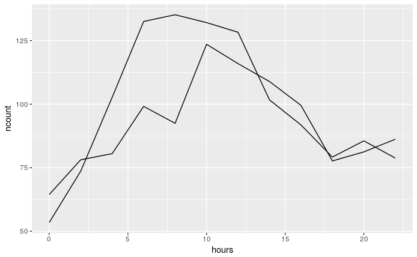